# Worked Example: Plants

Johan Larsson

Behnaz Pirzamanbein

Jonas Wallin

# 1 Carbon Dioxide Uptake in Grass Plants

In this example, we’ll take a look at an experiment on cold tolerance of the grass species [Echinochloa crus-galli](https://en.wikipedia.org/wiki/Echinochloa_crus-galli).

[figure not shown]

Figure 1: A specimen of Echinochloa crus-galli.

## 1.1 Data

The data we are going to look at is available in the `CO2` data set from **data sets** (a package that is part of the base R distribution). There are five variables:

- `Plant`: an ordered factor giving a unique identifier for each plant
- `Type`: a factor with levels giving the origin of the plant (Quebec or Mississippi)
- `Treatment`: a factor indicating if the sample was chilled or not
- `conc`: a numeric vector of ambient carbon dioxide concentrations (µL/L)
- `uptake`: a numeric vector of carbon dioxide uptake rates (µmol m⁻² s⁻¹)

The goal of the experiment was to investigate how carbon dioxide uptake is affected based on the ambient carbon dioxide concentration (`conc`), the origin of the plant `Type`, and `Treatment` (whether the plant was chilled overnight before the experiment started or not).

## 1.2 Simple Scatter Plot

Let’s start with the basics and just look at a scatter plot of the uptake and ambient concentration. We’ll map uptake to the y axis, and concentration to the x axis. Before starting, we’ll rename some variables for clearer default axis labels and convert `Plant` from an ordered to an unordered variable, as it’s not ordinal in nature. We’ll call the new data set `co2`.

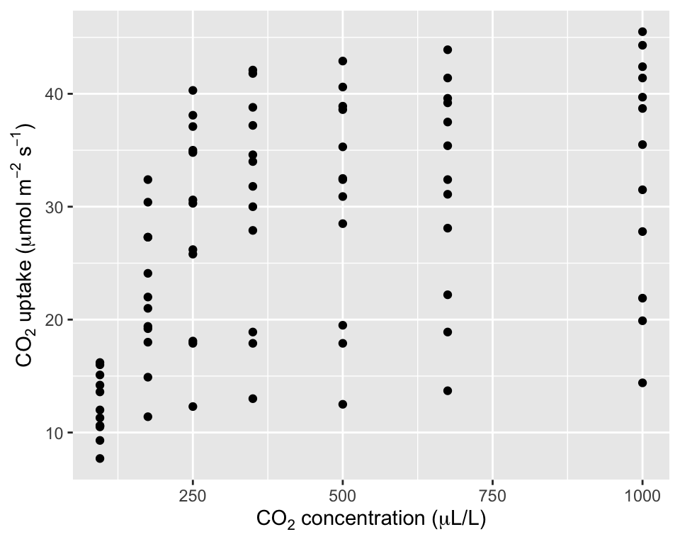

Figure 2: CO2 uptake and ambient CO2 concentration.

```r
library(tidyverse)

co2 <-
  CO2 %>%
  as_tibble() %>%
  rename(Concentration = conc, Origin = Type, Uptake = uptake) %>%
  mutate(Plant = factor(Plant, ordered = FALSE))

ggplot(co2, aes(Concentration, Uptake)) +
  geom_point() +
  labs(
    x = expression(paste("CO"[2], " concentration (", mu, "L/L)")),
    y = expression(paste("CO"[2], " uptake (", mu, "mol ", m^{-2}, " ", s^{-1}, ")"))
  )
```

## 1.3 Adding Lines

However, using only the point geom here is not a good design choice, since our data is actually *matched*, meaning that the observations belong to specific plants, and there are multiple measurements for each plant. There are several ways to show this. For instance, we could use color, facets, or simply a line geom with mappings to the group aesthetic to address this issue. In this case, we will try the latter option, but feel free to experiment with the other ideas as well.

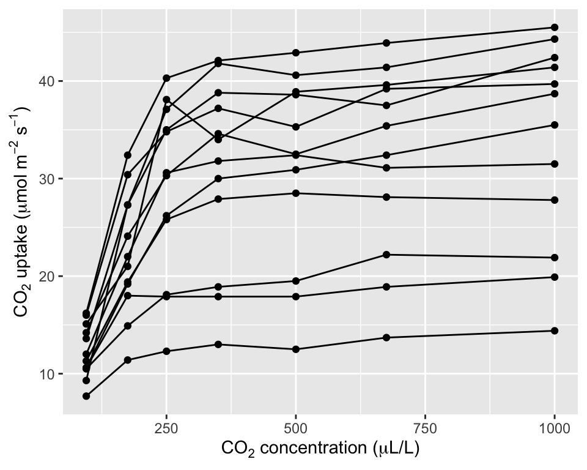

Figure 3: Ambient CO2 concentration and uptake for 12 plants in different conditions and from different origins.

```r
ggplot(co2, aes(Concentration, Uptake, group = Plant)) +
  geom_point() +
  geom_line() +
  labs(
    x = expression(paste("CO"[2], " concentration (", mu, "L/L)")),
    y = expression(paste("CO"[2], " uptake (", mu, "mol ", m^{-2}, " ", s^{-1}, ")"))
  )
```

Higher concentrations of CO2 evidently result in increased uptake of the same, which is not surprising. What kind of relationship would you describe this as? Please, take a moment to think about this.

## 1.4 Does Overnight Cooling Matter?

Until now, we haven’t included the other aspects of the experiment in our visualization. Let’s do that now. We will start by incorporating the cooling condition by mapping it to color. Also, it’s worth nothing that we have a natural color association here, with blue representing the cool condition, which we will certainly use.

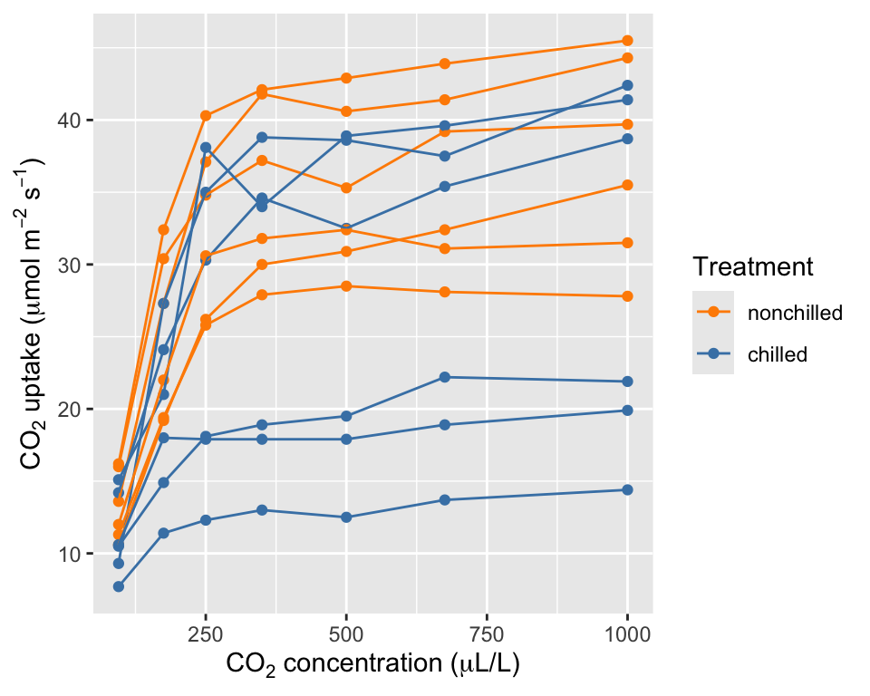

Figure 4: Ambient CO2 concentration and uptake for 12 plants under two different treatments (chilled overnight before the experiment or not).

```r
ggplot(co2, aes(Concentration, Uptake, group = Plant, color = Treatment)) +
  geom_point() +
  geom_line() +
  scale_color_manual(values = c("dark orange", "steel blue")) +
  labs(
    x = expression(paste("CO"[2], " concentration (", mu, "L/L)")),
    y = expression(paste("CO"[2], " uptake (", mu, "mol ", m^{-2}, " ", s^{-1}, ")"))
  )
```

## 1.5 Plant Origin

It appears that the uptake is generally improved in the non-chilled arm of the experiment, but there are two clear clusters here. Let’s explore whether the origin of the plants might help explain this bi-modal distribution.

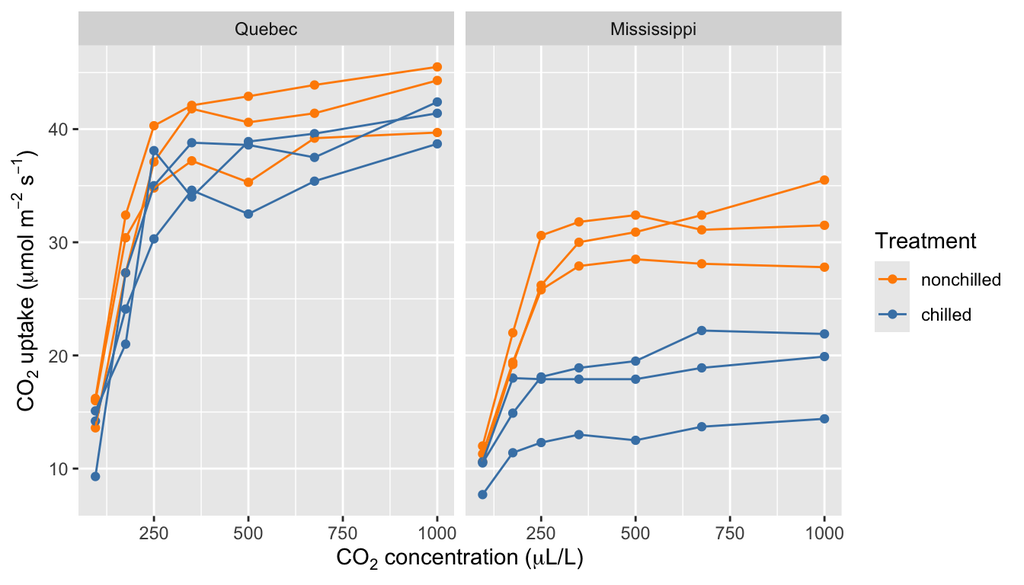

Figure 5: Ambient CO2 concentration and uptake for 12 plants under two different treatments (chilled overnight before the experiment or not) and from two different origins.

```r
ggplot(co2, aes(Concentration, Uptake, group = Plant, color = Treatment)) +
  geom_point() +
  geom_line() +
  facet_wrap("Origin") + # or vars(Origin) or ~ Origin
  scale_color_manual(values = c("dark orange", "steel blue")) +
  labs(
    x = expression(paste("CO"[2], " concentration (", mu, "L/L)")),
    y = expression(paste("CO"[2], " uptake (", mu, "mol ", m^{-2}, " ", s^{-1}, ")"))
  )
```

Yes, indeed, it appears that the origin of the plants explains this precisely. As we know, Mississippi is a much warmer state than Quebec, so it makes sense that we observe this adaptation in the plants in Quebec.

This example demonstrates the importance of exploring multivariate relationships by effectively *conditioning* your visualizations on certain variables.

## 1.6 Comparing Groups with a Linear Model

Can we make the same comparisons between origins and treatments using numbers rather than figures? Let’s use `lm()` to fit a simple model for a two-factor experiment.

Each plant was measured at seven concentrations. To keep the analysis simple, we will use only the measurements at **1000 µL/L**. Each plant then contributes one observation: there are 12 plants, with three plants in each combination of the two origins and two treatments. This compares uptake at one concentration; it does not model the full concentration-response curves. Using all 84 rows in an ordinary `lm()` as independent observations would ignore the repeated measurements on each plant.

First, select this concentration and calculate the four group means. Uptake is still measured in µmol m⁻² s⁻¹.

```r
co2_1000 <-
  co2 %>%
  filter(Concentration == 1000)

co2_1000 %>%
  group_by(Origin, Treatment) %>%
  summarise(Plants = n(), Mean_uptake = mean(Uptake), .groups = "drop") %>%
  knitr::kable(digits = 2)
```

| Origin | Treatment | Plants | Mean_uptake |
| --- | --- | --- | --- |
| Quebec | nonchilled | 3 | 43.17 |
| Quebec | chilled | 3 | 40.83 |
| Mississippi | nonchilled | 3 | 31.60 |
| Mississippi | chilled | 3 | 18.73 |

Now fit a model with both factors and their **interaction**. The formula `Origin * Treatment` expands to `Origin + Treatment + Origin:Treatment`. The interaction lets the difference between chilled and nonchilled plants depend on their origin. A linear model can compare group means like this; it does not require a numeric explanatory variable.

```r
plant_model <- lm(Uptake ~-1+ Origin * Treatment, data = co2_1000)
summary(plant_model)
```

```
##
## Call:
## lm(formula = Uptake ~ -1 + Origin * Treatment, data = co2_1000)
##
## Residuals:
##    Min     1Q Median     3Q    Max
## -4.333 -2.467  0.850  1.758  3.900
##
## Coefficients:
##                                    Estimate Std. Error t value     Pr(>|t|)
## OriginQuebec                         43.167      1.892  22.817 0.0000000144 ***
## OriginMississippi                    31.600      1.892  16.703 0.0000001670 ***
## Treatmentchilled                     -2.333      2.676  -0.872       0.4086
## OriginMississippi:Treatmentchilled  -10.533      3.784  -2.784       0.0238 *
## ---
## Signif. codes:  0 '***' 0.001 '**' 0.01 '*' 0.05 '.' 0.1 ' ' 1
##
## Residual standard error: 3.277 on 8 degrees of freedom
## Multiple R-squared:  0.9942, Adjusted R-squared:  0.9913
## F-statistic: 340.9 on 4 and 8 DF,  p-value: 0.000000005761
```

The reference group is **nonchilled plants from Quebec**. Read the coefficient table relative to this group. We use a 5% significance level and report individual p-values without adjustment for multiple comparisons.

What is the chilling difference in Mississippi itself? Adding the Quebec chilling coefficient and the interaction coefficient gives **−12.87**. To obtain its standard error and p-value directly, change the reference origin and fit the same model again.

```r
co2_1000_mississippi <-
  co2_1000 %>%
  mutate(Origin = relevel(Origin, ref = "Mississippi"))

mississippi_model <-
  lm(Uptake ~ -1 + Origin * Treatment, data = co2_1000_mississippi)

summary(mississippi_model)
```

```
##
## Call:
## lm(formula = Uptake ~ -1 + Origin * Treatment, data = co2_1000_mississippi)
##
## Residuals:
##    Min     1Q Median     3Q    Max
## -4.333 -2.467  0.850  1.758  3.900
##
## Coefficients:
##                               Estimate Std. Error t value     Pr(>|t|)
## OriginMississippi               31.600      1.892  16.703 0.0000001670 ***
## OriginQuebec                    43.167      1.892  22.817 0.0000000144 ***
## Treatmentchilled               -12.867      2.676  -4.809      0.00134 **
## OriginQuebec:Treatmentchilled   10.533      3.784   2.784      0.02378 *
## ---
## Signif. codes:  0 '***' 0.001 '**' 0.01 '*' 0.05 '.' 0.1 ' ' 1
##
## Residual standard error: 3.277 on 8 degrees of freedom
## Multiple R-squared:  0.9942, Adjusted R-squared:  0.9913
## F-statistic: 340.9 on 4 and 8 DF,  p-value: 0.000000005761
```

The Mississippi chilling difference is **−12.87**, with p = **0.0013**, so it is statistically significant. Changing the reference group changes the meaning of the coefficients, but leaves the fitted group means unchanged. Notice that the interaction test directly compares the two chilling effects: finding a significant effect in one origin and a nonsignificant effect in the other would not, by itself, establish a difference between them.

These tests assume independent plants and normally distributed errors with a common variance across the four groups. With only three plants per group, the conclusions depend on these assumptions. At this concentration, the numerical analysis supports the pattern in the faceted figure: chilling is associated with a much larger reduction in uptake for Mississippi plants.

# 2 Source Code

The source code for this document is available at https://github.com/stat-lu/dataviz/blob/main/worked-examples/plants.Rmd.